# SRM Chapter 6.1

theBudgetActuary

# Unsupervised Learning

The focus of all the previous chapters in this exam have been on supervised learning. This chapter will focus on unsupervised learning. With unsupervised learning we have no dependent variable so our goal is no longer to make predictions, instead our focus is finding relationships that exist within our data.

# Clustering Methods

This exam will focus on the two clustering methods of K-Means Clustering and Hierarchical Clustering. The goal of both these algorithms is to group observations in our data set based on similarities, however the way these two algorithms go about grouping the observations is very different.

# K-Means Clustering

K-means clustering works by grouping observations into a pre-specified number of groups, k. The goal of k-means clustering is to group observations in a way that minimizes the within-cluster variation, which is just how much the observations of a group differ from each other. (James et al.)

This within-cluster variation can be calculated using the squared euclidean distance.

$W(C_{k}) = \frac{1}{|C_{k}|} \sum_{i,i^{'}\in C_{k}} \sum_{j=1}^{p} (x_{ij}-x_{i^{'}j})^{2}$

## How it Works

K-means clustering starts by randomly assigning each observation in the data set to one of the k groups. It then assigns a centroid for each group, which is the value in the center of the points of that group, and also the point that creates the smallest within-cluster variation. For all subsequent iterations it reassigns observations to the nearest centroid, and then finds the new centroids for the reassigned observations. After each iteration, the total within cluster variation will decrease. If it does not decrease or the total number of iterations set is reached, the algorithm ends.

This process ultimately creates local minimums, which means the algorithm might not end up at the best feasible solution for grouping. In order to counter this the algorithm should be run multiple times. Whichever grouping resulted in the lowest total within cluster variation should be chosen as the final model. (James et al.)

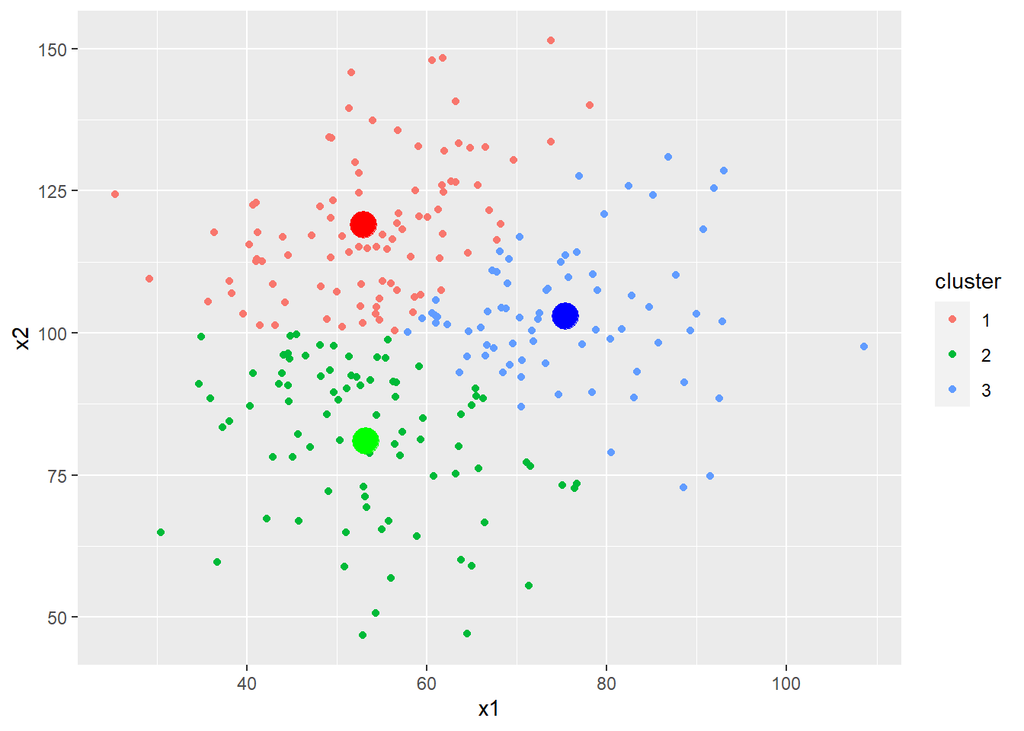

In the plot above there are three different groups, or k=3. The k-means algorithm has reached its conclusion meaning the centroids will no longer move as the observations will no longer change groups. The large dots represent the centroids of their respective categories.

#### Sources:

James, G., Witten, D., Hastie, T., & Tibshirani, R. (n.d.). An introduction to statistical learning: With applications in R.